### Random Variables

Formally, a random variable can be identified by a triple $(\Omega,\mathcal{F},P)$. Here ($\Omega$) consists of all possible elementary outcomes, ($\mathcal{F}$), sigma algebra, is a special collection of all possible events from $\Omega$ that have non-zero probabilities, $P$, probability, is a function that assigns a positive number to every event in $\mathcal{F}$ while satisfying probability constraints.

- Example of discrete distribution: Rolling a fair die
  - $\Omega = \{1, 2, 3, 4, 5, 6\}$
  - Events: All combinations of elementary outcomes $\{1, 2, 3, 4, 5, 6\}$
  - $P(\text{elementary event}) = 1/6$
- Example of continuous distributions:
  - $\Omega = \mathbb{R}$
  - Events: All combinations of semi-closed intervals $[a, b)$
  - $P([a, b]) = \text{CDF}(b) - \text{CDF}(a)$

Once you know the CDF, $P(x \leq a), \forall a$, you know everything about the random variable. However, we **cannot observe probabilities in real life**. They are mathematical abstractions. In practice, we observe **some numbers (observations)** from the (unknown) distribution of interest. How do we recover the CDF from observations? Population moments? We can estimate those using the empirical CDF:
$$P(X \leq a) = \frac{\sum_{i=1}^N I(x_i \leq
a)}{N}$$
Once the CDF is known, we can:

- Approximate the PDF (prone to outliers!)
- Construct sample moments that converge to population moments (assuming population moments exist)
- Construct critical values, compare distributions of interest etc.

The code below shows empirical cumulative distribution function for $N = 10, 1000$ of a mixture
$$x \sim 0.5 \times N(4,1) + 0.5 \times
\chi^2_{20}$$

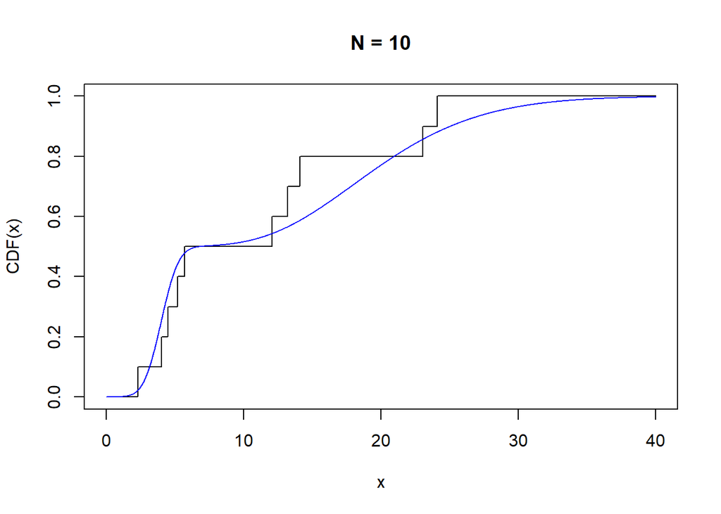

```r
N = 5
xrange = seq(0,40,0.01)
yrange = 0.5 * pnorm(xrange,4,1) + 0.5 * pchisq(xrange,20)

x_data1 = c(rchisq(N, 20), rnorm(N,mean = 4))
x_emp = ecdf(x_data1)
plot(xrange,x_emp(xrange), type = "l", main = "N = 10", ylab = "CDF(x)", xlab = "x")
lines(xrange, yrange, col = "blue")
```

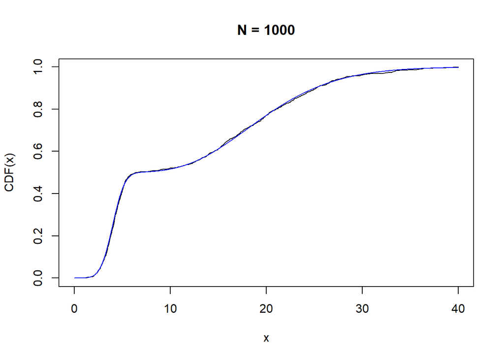

```r
N = 500
xrange = seq(0,40,0.01)
yrange = 0.5 * pnorm(xrange,4,1) + 0.5 * pchisq(xrange,20)

x_data2 = c(rchisq(N, 20), rnorm(N,mean = 4))
x_emp = ecdf(x_data2)
plot(xrange,x_emp(xrange), type = "l", main = "N = 1000", ylab = "CDF(x)", xlab = "x")
lines(xrange, yrange, col = "blue")
```

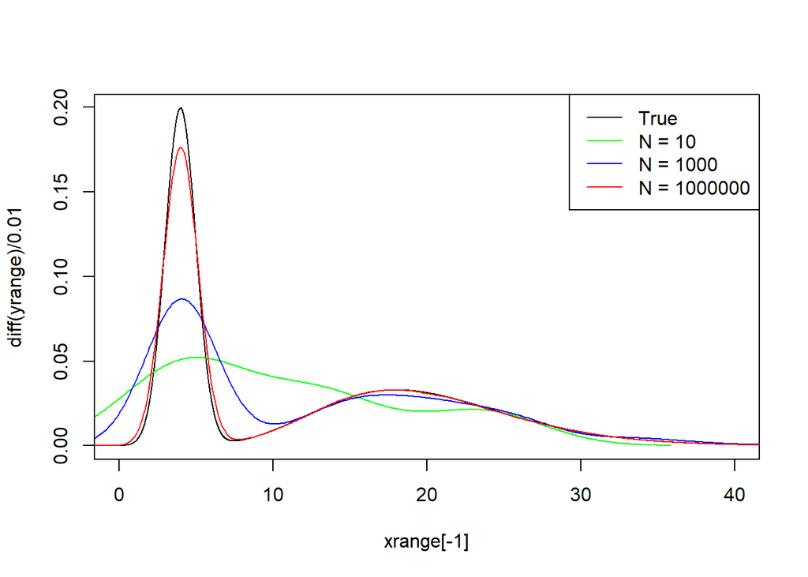

```r
N = 500000
x_data3 = c(rchisq(N, 20), rnorm(N,mean = 4))

s1 = density(x_data1)
s2 = density(x_data2)
s3 = density(x_data3)

plot(xrange[-1],diff(yrange)/0.01,type = "l")
lines(s1$x,s1$y,type = "l",col = "green")
lines(s2$x,s2$y,type = "l",col = "blue")
lines(s3$x,s3$y,type = "l",col = "red")
legend("topright",legend = c("True","N = 10","N = 1000","N = 1000000"), col = c("black","green","blue","red"),lty = 1)
```

### Importance of Uniform Distribution

How can we simulate observations from a given univariate monotone distribution? There is a well known fact: For any continuous random variable $X$ with a monotone CDF $F_X$:

$$F_X(X) \sim U(0, 1)$$
$$F_X^{-1}(U) \sim F_X(X)$$

Thus, we need to figure out how to generate observations from uniform $(0,1)$.

- Algorithm:
  1. Generate an observation from $U(0,1)$.
  2. Apply the inverse CDF of the distribution of interest.
  3. Report the result.
- Generating iid observations from $U(0,1)$:
  - Physical devices (e.g., RAND 1955, "A Million Random Digits with 100,000 Normal Deviates", 8 years to create, electronic roulette with additional adjustments; hardware noise) are expensive and not always needed.
  - Pseudo-random number generators provide a cost-effective alternative.

### Pseudo-Random Number Generators (Software Implementation)

They generates deterministic periodic sequences **that appear** iid from $U(0,1)$. One of the oldest is Linear Congruential Generator.
$$X_{i+1} = (aX_i + c) \mod m$$
$$R_{i+1} = X_{i+1}/m$$
where $a$, $c$, and $m$ are carefully chosen constants. The period (up to $10^{64}$) and properties depend on the parameters.Modern generators (e.g., Mersenne Twister) produce high-quality uniform-looking sequences with periods of up to $4.3 \times 10^{6001}$ and looks like
$$X_{i+n} =
f(X_{i+n-1},X_{i+n-2},\ldots,X_i )$$
- Pros: Once the initial states ($X_i$, $X_{i+n-1},X_{i+n-2},\ldots,X_i$) are known, the following sequence of pseudo random numbers can be replicated. - Cons: Cyclic behavior, deviations from uniformity, and correlations (mostly resolved in modern algorithms), predictability once the state is known.

To set a random state in R, you have to use `set.seed()` command. Once the state is set, every call of the random number generator shifts the state further down the line.

```r
set.seed(1)
rnorm(3)
```

```
## [1] -0.626  0.184 -0.836
```

```r
rnorm(3)
```

```
## [1]  1.60  0.33 -0.82
```

```r
set.seed(1)
rnorm(6)
```

```
## [1] -0.626  0.184 -0.836  1.595  0.330 -0.820
```

Moreover, every time you start R, the state resets to the same position. Say, running `rnorm(1)` as a first command gives you $-0.1612836$.

### Benefits of (Monte Carlo) simulations

Real-world data **always** have only one sample. We **never** know if observations come from the same DGP. The true relationships between variables are unknown. The distribution and dependence of error terms are unknown.

In the simulations you **know** the DGP. You **know** whether regressors are endogenous or exogenous. You **know** the distribution of error terms. You can generate as many samples as you want.

### Monte Carlo Simulation Steps

1. Specify the Data Generating Process (DGP):  
   Define $y$, $X$, coefficients $\beta$, sample size $N$, and the error term $u$.
2. Generate $N$ observations of $u$ from the chosen error distribution.
3. Generate $N$ observations of $y$ from the DGP:
   $$y = f(X, \beta) + u$$
4. Apply the estimator (e.g., $\beta_{\text{OLS}}$) and record the estimate.
5. Repeat Steps 2–4 for 10,000–1,000,000 samples.
6. Analyze results (distributions, graphs, etc.).

In this meeting we will study some properties of stationary/non-stationary processes.

### Stationary/non-stationary processes

The simplest non-stationary proccess integrated of order one would be
$$y_t = y_{t-1}+\epsilon_t$$
It has a special name random walk.

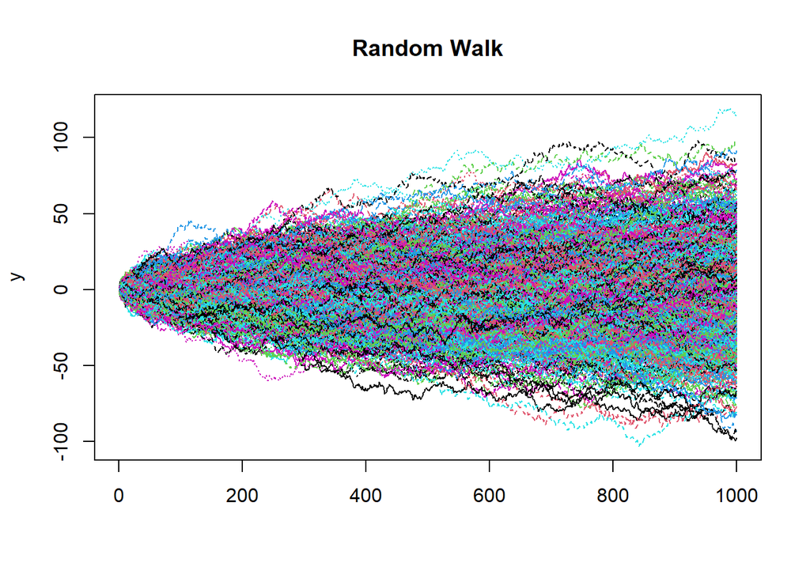

```r
N = 1000
T=1000
set.seed(1)
y = apply(matrix(rnorm(T * N),T,N), 1, cumsum)
#y_sqrtt <- y/(sqrt(matrix(1:T,T,1))%*%matrix(1,1,N))
y_sqrtT <- y/sqrt(T)

#layout(matrix(c(1,2,3,4,5,6), 2, 3, byrow = TRUE))
matplot(y,type = "l",main = "Random Walk")
```

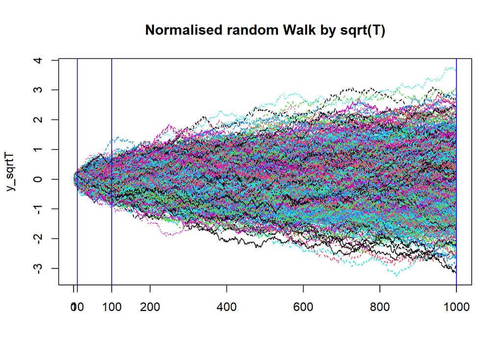

```r
#matplot(y_sqrtt,type = "l",main = "Normalised random Walk by sqrt(t)")
matplot(y_sqrtT,type = "l",main = "Normalised random Walk by sqrt(T)")
axis(1, at = c(10, 100))
abline(v=c(10,100,1000),col="blue")
```

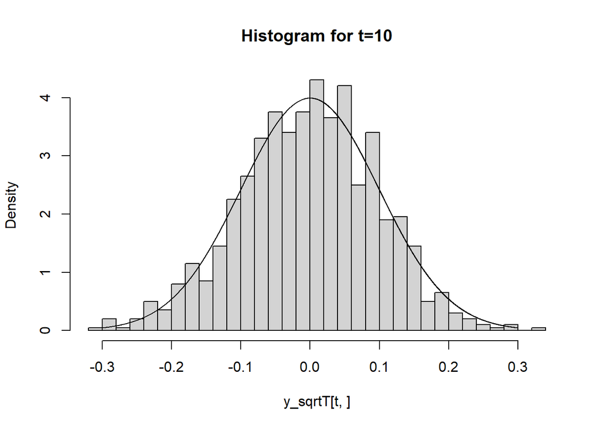

```r
t = 10
hist(y_sqrtT[t,],breaks = 40,freq = FALSE,main = "Histogram for t=10")
x <- seq(-sqrt(t/T)*3,sqrt(t/T)*3,t/T/100)
lines(x,dnorm(x,0,sqrt(t/T)),type = "l")
```

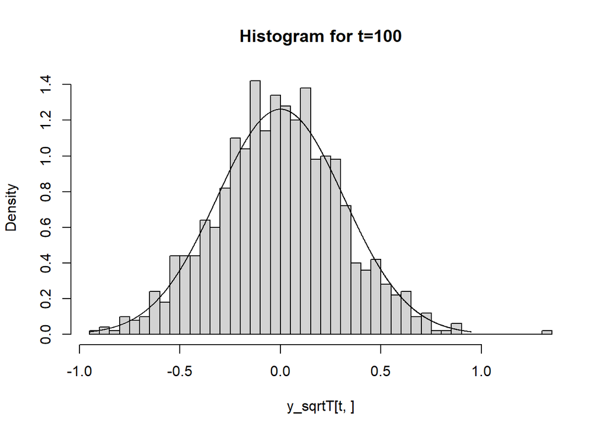

```r
t = 100
hist(y_sqrtT[t,],breaks = 40,freq = FALSE,main = "Histogram for t=100")
x <- seq(-sqrt(t/T)*3,sqrt(t/T)*3,t/T/100)
lines(x,dnorm(x,0,sqrt(t/T)),type = "l")
```

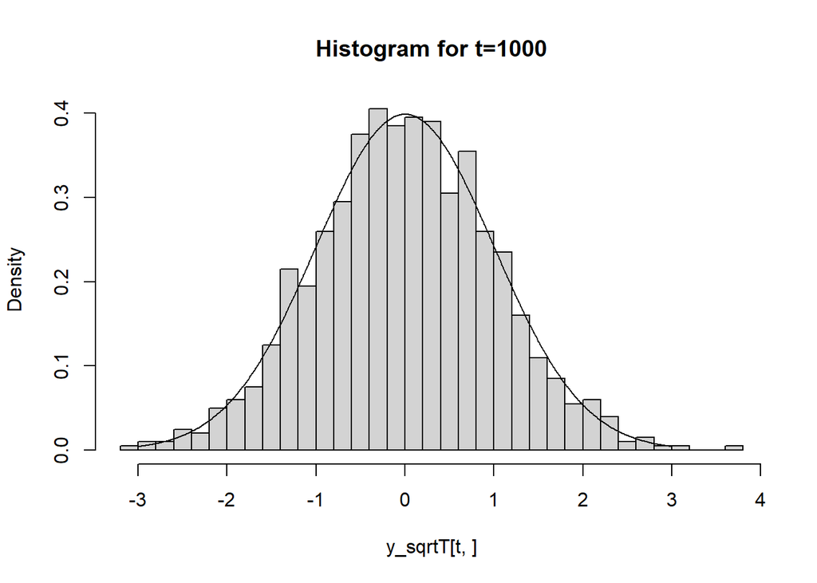

```r
t = 1000
hist(y_sqrtT[t,],breaks = 40,freq = FALSE,main = "Histogram for t=1000")
x <- seq(-sqrt(t/T)*3,sqrt(t/T)*3,t/T/100)
lines(x,dnorm(x,0,sqrt(t/T)),type = "l")
```

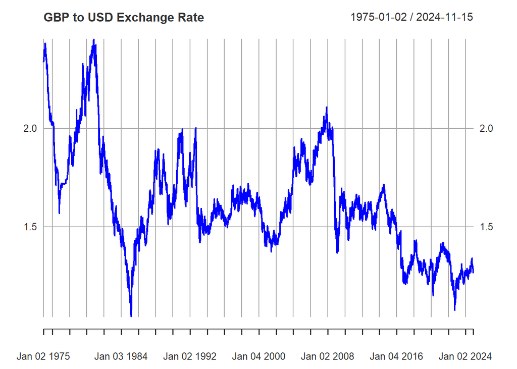

```r
#matplot(y_sqrtT[,c(1,3,10,20)],type = "l",main = "Normalised random Walk by sqrt(T)")
gbpusd <- pdfetch_BOE("XUDLUSS",from = "1965-01-01")
plot(gbpusd,col="blue", main = "GBP to USD Exchange Rate")
```

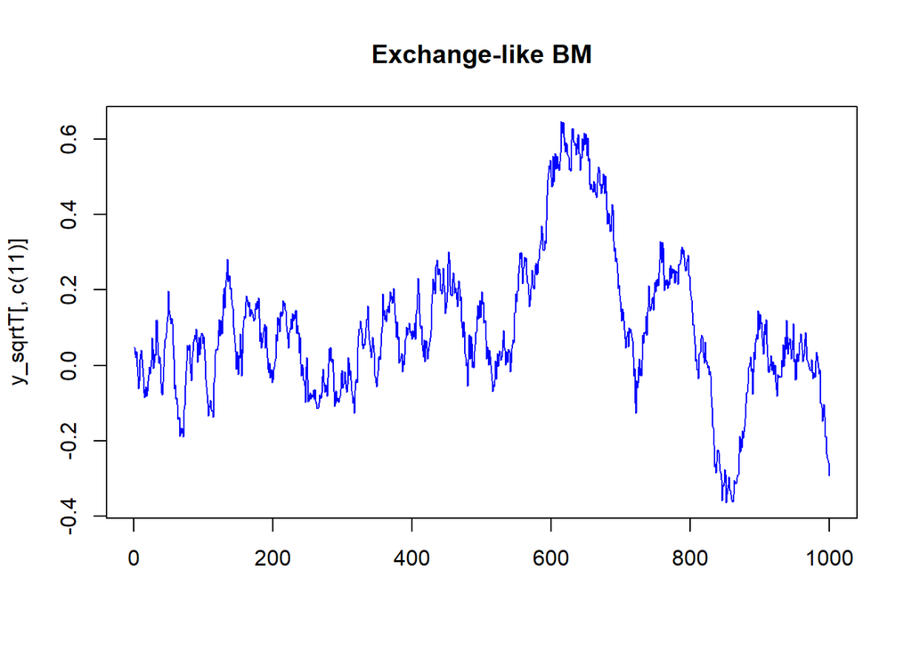

```r
matplot(y_sqrtT[,c(11)],type = "l",main = "Exchange-like BM",col = "blue")
```

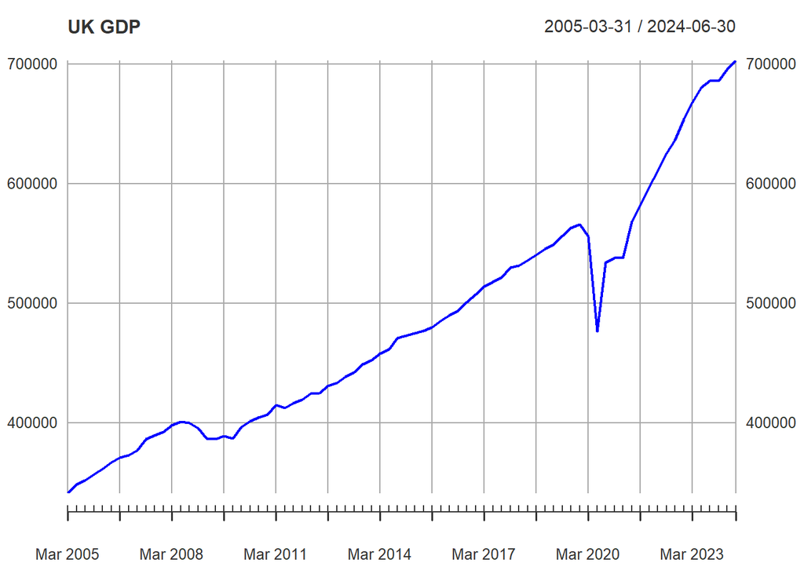

```r
UK_GDP <- pdfetch_FRED("UKNGDP")
plot(UK_GDP["2005::"],col="blue", main = "UK GDP")
```

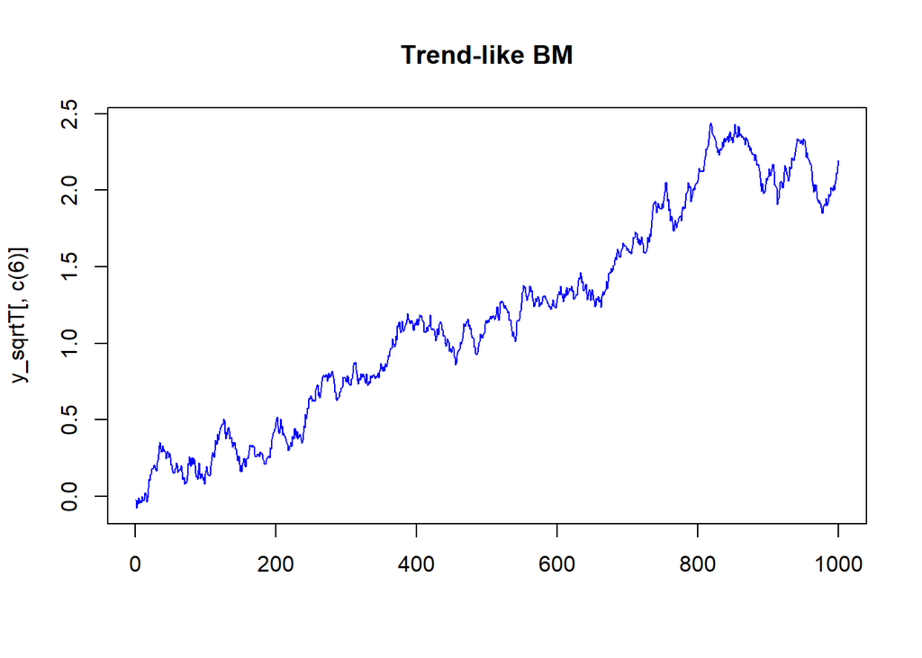

```r
matplot(y_sqrtT[,c(6)],type = "l",main = "Trend-like BM",col="blue")
```

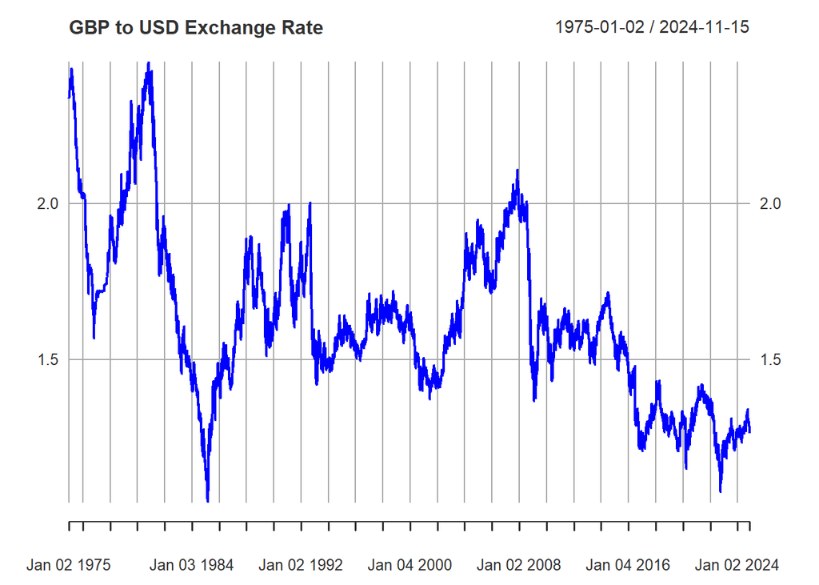

```r
gbpusd <- pdfetch_BOE("XUDLUSS",from = "1965-01-01")
plot(gbpusd,col="blue", main = "GBP to USD Exchange Rate")
```

The last two pairs of the data look quite similar. Moreover, once you try to fit one series using the other as explanatory variable, you might find that the relationship would be statistically significant there. This fit, however, would be spurious. It is a common situation once a person regresses one non-stationary series on another. This is due to the fact that for non-stationary series statistical inference cannot, in general, rely on standard central limit theorem aka asymptotic normality. Let's look at it in more details.

### Random Walk Dickey-Fuller $\tau$-distribution

```r
N = 10000
T = 1000
set.seed(1)
data = matrix(rnorm(T * N),T,N)
y0 = apply(data, 2, cumsum)
xx = y0[-T,]
yy = y0[-1,] - y0[-T,]
tt = seq(1,T-1)
tau <- tau1 <- tau2 <- tau3 <- matrix(0,N,1)
for (i in seq(1,N)){
  y = yy[,i]
  x = xx[,i]
  temp = ur.df(y0[,i], type = "drift", lags = 0)
  tau[i] = temp@teststat[1]
  temp = summary(lm(formula =  y ~ x+0))
  tau1[i] = temp$coefficients[3]
  temp = summary(lm(formula =  y ~ x))
  tau2[i] = temp$coefficients[2,3]
  temp = summary(lm(formula =  y ~ x+tt))
  tau3[i] = temp$coefficients[2,3]
}
# Critical values for normally distributed r.v.
quantile(rnorm(10000), probs = c(0.01,0.05,0.1))
```

```
##    1%    5%   10%
## -2.34 -1.64 -1.28
```

```r
# Critical values for DF model 1 r.v.
quantile(tau1, probs = c(0.01,0.05,0.1))
```

```
##    1%    5%   10%
## -2.56 -1.92 -1.58
```

```r
# Critical values for DF model 2 r.v.
quantile(tau2, probs = c(0.01,0.05,0.1))
```

```
##    1%    5%   10%
## -3.44 -2.84 -2.57
```

```r
# Critical values for DF model 3 r.v.
quantile(tau3, probs = c(0.01,0.05,0.1))
```

```
##    1%    5%   10%
## -4.03 -3.43 -3.13
```

```r
# Critical values for DF using urca package for Models 1, 2, 3
qunitroot(c(0.01,0.05,.1), trend = "nc",N = 1000)
```

```
## [1] -2.57 -1.94 -1.62
```

```r
qunitroot(c(0.01,0.05,.1), trend = "c",N = 1000)
```

```
## [1] -3.44 -2.86 -2.57
```

```r
qunitroot(c(0.01,0.05,.1), trend = "ct",N = 1000)
```

```
## [1] -3.97 -3.41 -3.13
```

As you can see,

1. Critical values for Dickey-Fuller test are significantly different from Normal/t-distributions
2. Critical values for Dickey-Fuller test depend on the model fitted
3. The simulated ones are very close to the simulated ones from `urca` package.

Below you can see simulated pdfs for these four cases with corresponding critical values.

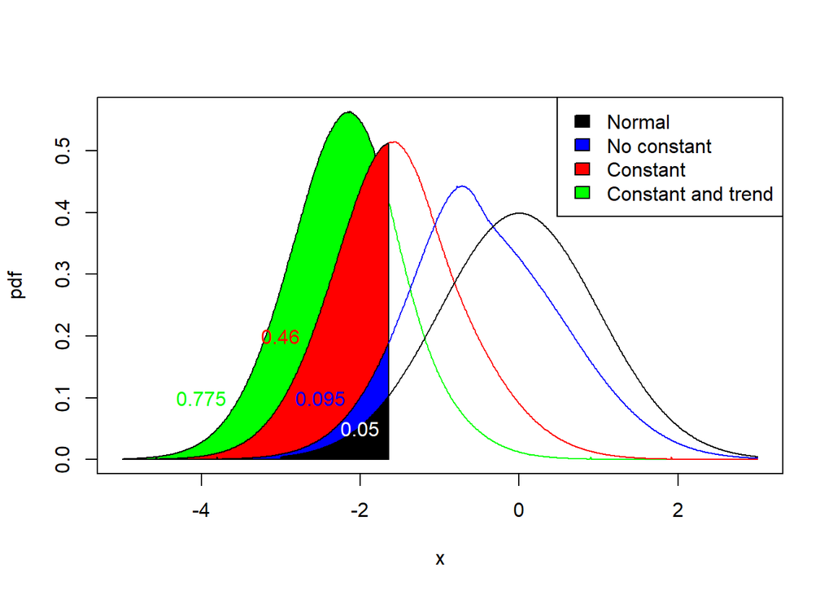

```r
require(urca)
zcrit = qnorm(0.05)
plot(seq(-4.99,3,0.01),diff(punitroot(seq(-5,3,0.01),trend = "ct"))*100,type = "l",col = "green",xlab = "x", ylab = "pdf")
x = c(-4.99,seq(-4.99,zcrit,0.01),zcrit)
y = c(0,diff(punitroot(seq(-5,zcrit,0.01),trend = "ct")*100),0)
polygon(x,y,col = "green")
text(-4,0.1,paste(round(punitroot(zcrit,trend = "ct"),digits = 3)),col = "green")


lines(seq(-4.99,3,0.01),diff(punitroot(seq(-5,3,0.01),trend = "c"))*100,type = "l",col = "red")
y = c(0,diff(punitroot(seq(-5,zcrit,0.01),trend = "c")*100),0)
polygon(x,y,col = "red")
text(-3,0.2,paste(round(punitroot(zcrit,trend = "c"),digits = 3)),col = "red")

lines(seq(-4.99,3,0.01),diff(punitroot(seq(-5,3,0.01),trend = "nc"))*100,type = "l",col = "blue")
y = c(0,diff(punitroot(seq(-5,zcrit,0.01),trend = "nc")*100),0)
polygon(x,y,col = "blue")
text(-2.5,0.1,paste(round(punitroot(zcrit,trend = "nc"),digits = 3)),col = "blue")


lines(seq(-3,3,0.01),dnorm(seq(-3,3,0.01)),type = "l",col = "black")
x = c(-3,seq(-3,zcrit,0.01),zcrit)
y = c(0,dnorm(seq(-3,zcrit,0.01)),0)
polygon(x,y,col = "black")
text(-2,0.05,paste(round(pnorm(zcrit),digits = 3)),col = "white")

legend("topright",c("Normal","No constant","Constant","Constant and trend"),fill = c("black","blue","red","green"))
```

### Empirical applications.

Last time we were discussing FRED-MD dataset. The authors applied different transformations to different variables in the dataset. Some transformed to logs, some - first differences, some - the second. Lets download the dataset and check for transformed series:

```r
cleaned_data <- function(data){
data.md.clean <- rm_outliers.fredmd(data)
col_na_prop <- apply(is.na(data.md.clean), 2, mean)
data.md.select <- data.md.clean[, (col_na_prop < 0.05)]
data.md.select.2 <- na.omit(data.md.select)
return(data.md.select.2)
}

filepath <- "https://files.stlouisfed.org/files/htdocs/fred-md/monthly/2024-09.csv"
data.md <- fredmd(filepath, date_start = NULL, date_end = NULL, transform = TRUE) |> cleaned_data()
data.md.0 <- fredmd(filepath, date_start = NULL, date_end = NULL, transform = FALSE) |> cleaned_data()
data_des <- describe_md(names(data.md))
```

Lets select the variables that are not transformed and plot one of those

```r
ind_no_transform = data_des$tcode == 1
data_no_transform = data.md.0[,ind_no_transform]
temp = names(data_no_transform)
for (i in seq(1,3)){
  print(temp[i])
  summary(ur.df(data_no_transform[,i],type = "drift",selectlags = "AIC")) |> print()
}
```

```
## [1] "CES0600000007"
##
## ###############################################
## # Augmented Dickey-Fuller Test Unit Root Test #
## ###############################################
##
## Test regression drift
##
##
## Call:
## lm(formula = z.diff ~ z.lag.1 + 1 + z.diff.lag)
##
## Residuals:
##    Min     1Q Median     3Q    Max
## -2.173 -0.114  0.016  0.128  1.410
##
## Coefficients:
##             Estimate Std. Error t value Pr(>|t|)
## (Intercept)   2.3833     0.5814     4.1 0.000046 ***
## z.lag.1      -0.0591     0.0144    -4.1 0.000046 ***
## z.diff.lag   -0.3525     0.0338   -10.4  < 2e-16 ***
## ---
## Signif. codes:  0 '***' 0.001 '**' 0.01 '*' 0.05 '.' 0.1 ' ' 1
##
## Residual standard error: 0.25 on 765 degrees of freedom
## Multiple R-squared:  0.165,  Adjusted R-squared:  0.163
## F-statistic: 75.4 on 2 and 765 DF,  p-value: <2e-16
##
##
## Value of test-statistic is: -4.1 8.41
##
## Critical values for test statistics:
##       1pct  5pct 10pct
## tau2 -3.43 -2.86 -2.57
## phi1  6.43  4.59  3.78
##
## [1] "AWHMAN"
##
## ###############################################
## # Augmented Dickey-Fuller Test Unit Root Test #
```

[output cut: 52 more lines]

```
## z.diff.lag   0.14625    0.03572    4.09  4.7e-05 ***
## ---
## Signif. codes:  0 '***' 0.001 '**' 0.01 '*' 0.05 '.' 0.1 ' ' 1
##
## Residual standard error: 0.37 on 765 degrees of freedom
## Multiple R-squared:  0.0858, Adjusted R-squared:  0.0834
## F-statistic: 35.9 on 2 and 765 DF,  p-value: 1.26e-15
##
##
## Value of test-statistic is: -8.21 33.7
##
## Critical values for test statistics:
##       1pct  5pct 10pct
## tau2 -3.43 -2.86 -2.57
## phi1  6.43  4.59  3.78
```

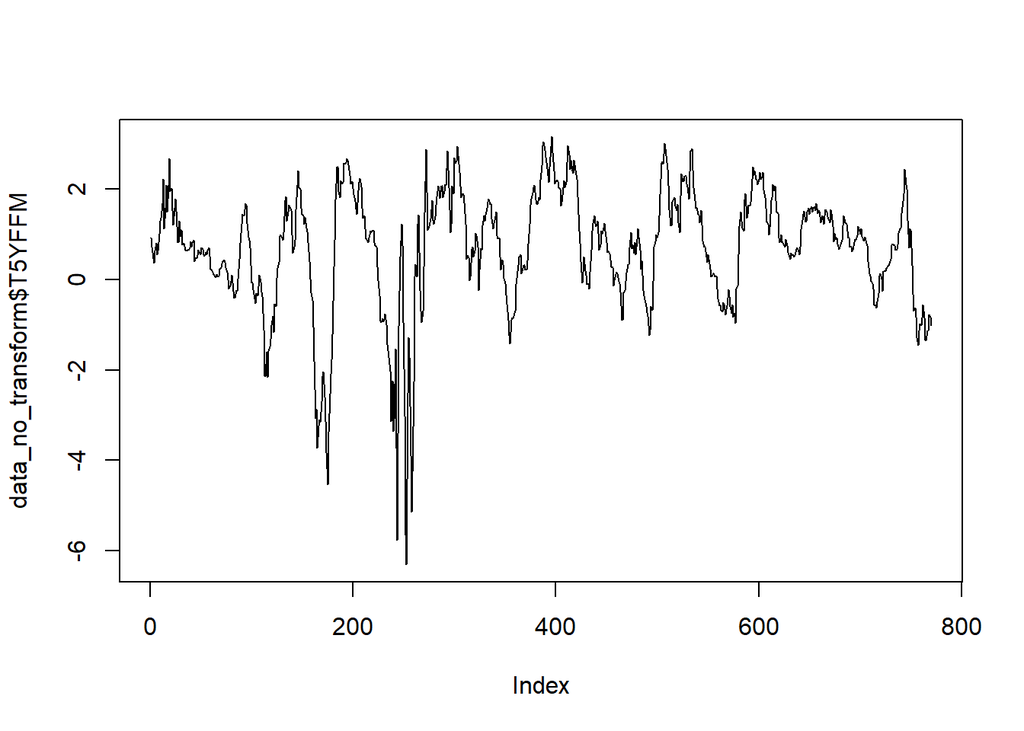

```r
plot(data_no_transform$T5YFFM, type = "l")
```

Let's check the second difference series of natural logs, "INVEST"

```r
describe_md("INVEST")
```

```
##       fred                                       description tcode
## 134 INVEST Securities in Bank Credit at All Commercial Banks     6
##                                                                   ttype
## 134 Second difference of natural log: (ln(x)-ln(x-1))-(ln(x-1)-ln(x-2))
```

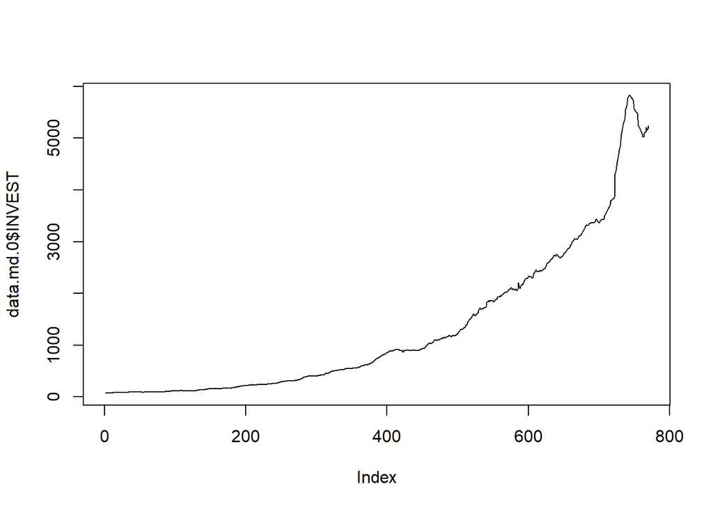

```r
plot(data.md.0$INVEST, type = "l")
```

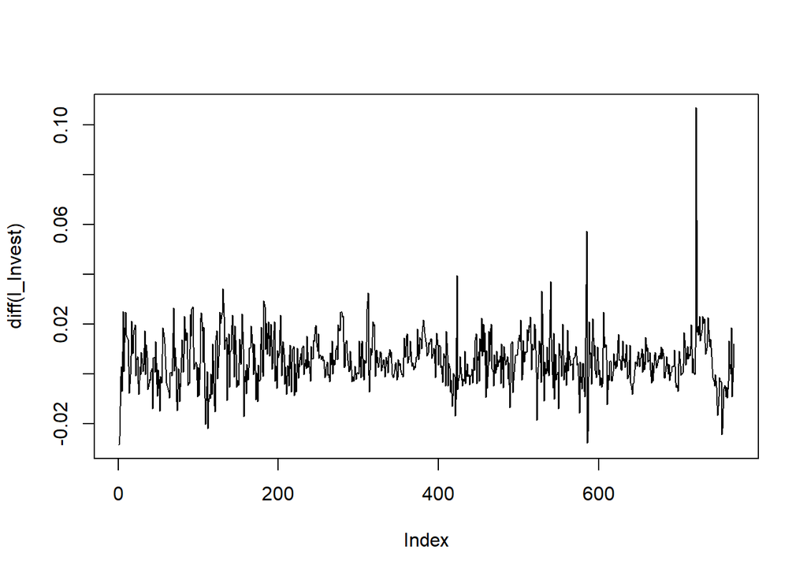

```r
l_Invest <- log(data.md.0$INVEST)
plot(diff(l_Invest), type = "l")
```

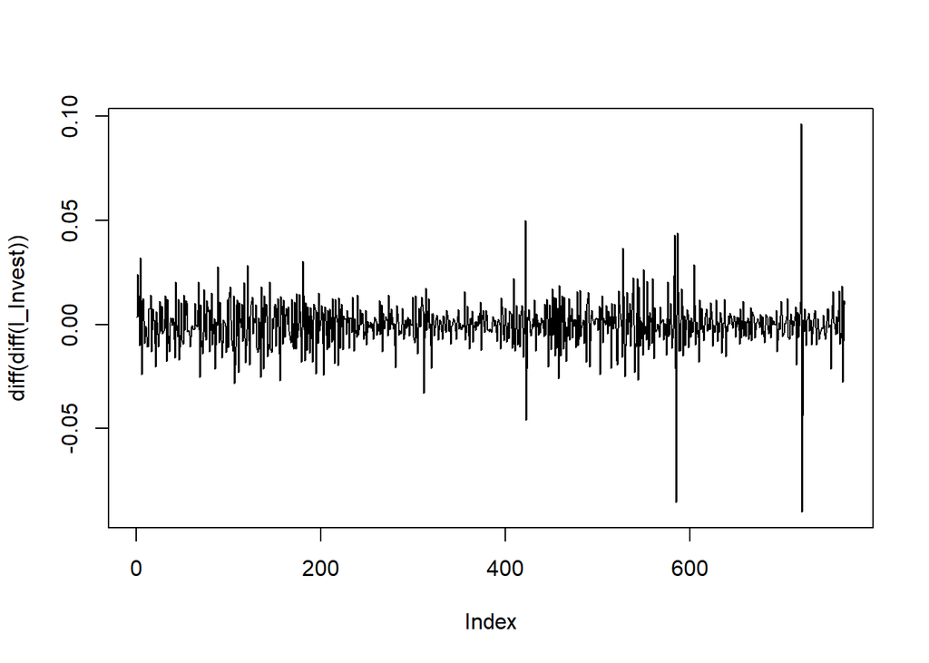

```r
plot(diff(diff(l_Invest)), type = "l")
```

```r
  summary(ur.df(l_Invest,type = "trend",selectlags = "AIC"))
```

```
##
## ###############################################
## # Augmented Dickey-Fuller Test Unit Root Test #
## ###############################################
##
## Test regression trend
##
##
## Call:
## lm(formula = z.diff ~ z.lag.1 + 1 + tt + z.diff.lag)
##
## Residuals:
##      Min       1Q   Median       3Q      Max
## -0.05104 -0.00534 -0.00025  0.00507  0.09843
##
## Coefficients:
##               Estimate Std. Error t value Pr(>|t|)
## (Intercept)  0.0357172  0.0159756    2.24    0.026 *
## z.lag.1     -0.0075833  0.0037987   -2.00    0.046 *
## tt           0.0000438  0.0000223    1.97    0.050 *
## z.diff.lag   0.3532605  0.0336184   10.51   <2e-16 ***
## ---
## Signif. codes:  0 '***' 0.001 '**' 0.01 '*' 0.05 '.' 0.1 ' ' 1
##
## Residual standard error: 0.00952 on 764 degrees of freedom
## Multiple R-squared:  0.128,  Adjusted R-squared:  0.125
## F-statistic: 37.5 on 3 and 764 DF,  p-value: <2e-16
##
##
## Value of test-statistic is: -2 30.3 2.06
##
## Critical values for test statistics:
##       1pct  5pct 10pct
## tau3 -3.96 -3.41 -3.12
## phi2  6.09  4.68  4.03
## phi3  8.27  6.25  5.34
```

```r
  summary(ur.df(diff(l_Invest),type = "drift",selectlags = "AIC"))
```

```
##
## ###############################################
## # Augmented Dickey-Fuller Test Unit Root Test #
## ###############################################
##
## Test regression drift
##
##
## Call:
## lm(formula = z.diff ~ z.lag.1 + 1 + z.diff.lag)
##
## Residuals:
##      Min       1Q   Median       3Q      Max
## -0.05063 -0.00539 -0.00027  0.00503  0.09988
##
## Coefficients:
##              Estimate Std. Error t value Pr(>|t|)
## (Intercept)  0.003568   0.000411    8.67   <2e-16 ***
## z.lag.1     -0.633899   0.040927  -15.49   <2e-16 ***
## z.diff.lag  -0.038805   0.035817   -1.08     0.28
## ---
## Signif. codes:  0 '***' 0.001 '**' 0.01 '*' 0.05 '.' 0.1 ' ' 1
##
## Residual standard error: 0.00952 on 764 degrees of freedom
## Multiple R-squared:  0.333,  Adjusted R-squared:  0.332
## F-statistic:  191 on 2 and 764 DF,  p-value: <2e-16
##
##
## Value of test-statistic is: -15.5 120
##
## Critical values for test statistics:
##       1pct  5pct 10pct
## tau2 -3.43 -2.86 -2.57
## phi1  6.43  4.59  3.78
```

```r
  summary(ur.df(diff(diff(l_Invest)),type = "drift",selectlags = "AIC"))
```

```
##
## ###############################################
## # Augmented Dickey-Fuller Test Unit Root Test #
## ###############################################
##
## Test regression drift
##
##
## Call:
## lm(formula = z.diff ~ z.lag.1 + 1 + z.diff.lag)
##
## Residuals:
##      Min       1Q   Median       3Q      Max
## -0.05616 -0.00536  0.00044  0.00483  0.10120
##
## Coefficients:
##               Estimate Std. Error t value Pr(>|t|)
## (Intercept)  0.0000429  0.0003669    0.12     0.91
## z.lag.1     -1.8373040  0.0554831  -33.11   <2e-16 ***
## z.diff.lag   0.3577752  0.0337310   10.61   <2e-16 ***
## ---
## Signif. codes:  0 '***' 0.001 '**' 0.01 '*' 0.05 '.' 0.1 ' ' 1
##
## Residual standard error: 0.0102 on 763 degrees of freedom
## Multiple R-squared:  0.719,  Adjusted R-squared:  0.718
## F-statistic:  977 on 2 and 763 DF,  p-value: <2e-16
##
##
## Value of test-statistic is: -33.1 548
##
## Critical values for test statistics:
##       1pct  5pct 10pct
## tau2 -3.43 -2.86 -2.57
## phi1  6.43  4.59  3.78
```

### Trend-stationarity and Overdifferencing

Overdifferencing happens when you take differences of data that’s already trend-stationary, which can mess up your analysis. For example, if your time series $y_t$ can be written as

$$y_t = \alpha + \beta t + u_t$$

where $\alpha + \beta t$ is the trend and $u_t$ is white noise, differencing it once gives $\Delta y_t = \beta + \Delta u_t$. This removes the trend (the $\beta t$) and leaves a stationary series, which is fine. But instead, it introduces artificial dependence between times $t$ and $t-1$, as $Cov(\Delta u_t,\Delta u_{t-1}) \ne 0$. This makes it harder to interpret or model the data correctly, and any forecasts could become unreliable. A way better strategy would be to test for non-stationarity vs trend-stationarity using proper non-stationarity tests. The same logic applies for stationary $u_t$ and for arbitrary deterministic trend $f(t)$.

In the following example, the correct relationship is as above, however the researcher decided to use first differenced series.

```r
T = 10000
e = rnorm(T,1)
t = seq(1,T)
a = 1
b = 2
y = a + b * t + e
y_obs = y[-1]
x_obs = y[-T]
t_obs = t[-1]
summary(lm(formula = y_obs~x_obs+t_obs))
```

```
##
## Call:
## lm(formula = y_obs ~ x_obs + t_obs)
##
## Residuals:
##    Min     1Q Median     3Q    Max
## -3.897 -0.682 -0.004  0.670  4.122
##
## Coefficients:
##             Estimate Std. Error t value Pr(>|t|)
## (Intercept)  1.97305    0.02000   98.65   <2e-16 ***
## x_obs       -0.00778    0.01000   -0.78     0.44
## t_obs        2.01556    0.02000  100.76   <2e-16 ***
## ---
## Signif. codes:  0 '***' 0.001 '**' 0.01 '*' 0.05 '.' 0.1 ' ' 1
##
## Residual standard error: 1 on 9996 degrees of freedom
## Multiple R-squared:     1,   Adjusted R-squared:     1
## F-statistic: 1.67e+11 on 2 and 9996 DF,  p-value: <2e-16
```

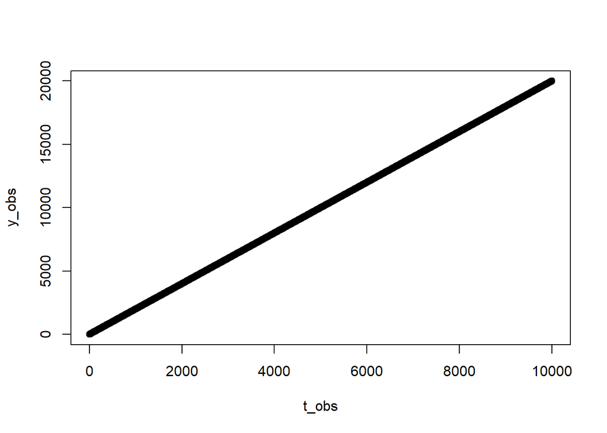

```r
plot(t_obs,y_obs)
```

```r
summary(lm(formula = diff(y_obs)~diff(x_obs)+t_obs[-1]))
```

```
##
## Call:
## lm(formula = diff(y_obs) ~ diff(x_obs) + t_obs[-1])
##
## Residuals:
##    Min     1Q Median     3Q    Max
## -4.444 -0.817  0.000  0.832  4.863
##
## Coefficients:
##              Estimate Std. Error t value Pr(>|t|)
## (Intercept)  3.02e+00   2.98e-02  101.34   <2e-16 ***
## diff(x_obs) -5.12e-01   8.59e-03  -59.56   <2e-16 ***
## t_obs[-1]   -6.56e-08   4.22e-06   -0.02     0.99
## ---
## Signif. codes:  0 '***' 0.001 '**' 0.01 '*' 0.05 '.' 0.1 ' ' 1
##
## Residual standard error: 1.22 on 9995 degrees of freedom
## Multiple R-squared:  0.262,  Adjusted R-squared:  0.262
## F-statistic: 1.77e+03 on 2 and 9995 DF,  p-value: <2e-16
```

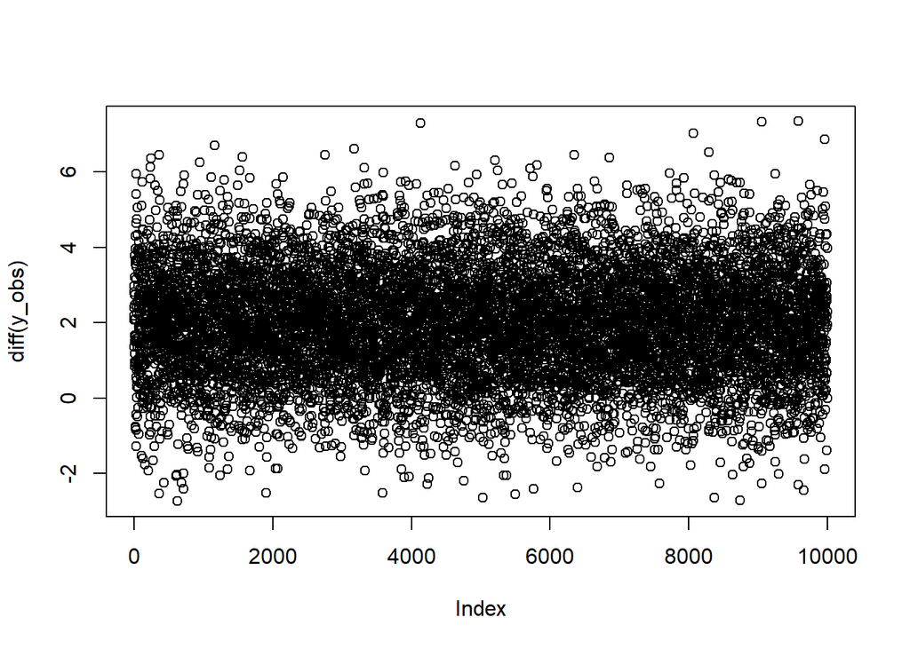

```r
plot(diff(y_obs))
```

The same applies once seasonal non-stationarity is present, say

$$y_t = y_{t-2}+u_t$$
First-differencing this series will lead to introducing artificial structure to the process.